# Simulation Models of Cultural Evolution

Alex Mesoudi

# Model 1: Unbiased transmission

Here we will simulate a case where $N$ individuals each possess one of two cultural traits, denoted $A$ and $B$. Each generation, the $N$ agents are replaced with $N$ new agents. Each new agent picks a member of the previous generation at random and copies their cultural trait. This is known as unbiased oblique cultural transmission: unbiased because traits are copied entirely at random, and oblique because one generation learns from the previous non-overlapping generation (as opposed to horizontal cultural transmission where individuals copy members of the same generation, and vertical cultural transmission where offspring copy their parents - our model is way too simple to have actual parents and offspring though).

We are interested in tracking the proportion of individuals who possess trait $A$ over successive generations. We will call this proportion $p$. We could also track the proportion who possess trait $B$, but this will always be $1 - p$ given that everyone who does not possess $A$ must possess $B$, so there is really no need. For example, if 70% of the population have trait $A$, then $p = 0.7$. The remaining 30% must have trait $B$, which is a proportion $1 - p = 1 - 0.7 = 0.3$.

The output of the model will be a plot showing $p$ over all generations up to the last generation, which we will call $t_{max}$. Generations (aka timesteps) are denoted by $t$, where generation one is $t = 1$, generation two is $t = 2$, up to the last generation $t = t_{max}$. These could correspond to biological generations, but could equally be ‘cultural generations’ (or learning episodes), which might be much shorter.

First we need to specify the fixed parameters of the model. These are $N$ (the number of individuals) and $t_{max}$ (the number of generations). Let’s start with $N = 100$ and $t_{max} = 200$.

```r
N <- 100
t_max <- 200
```

Run this code snippet using the green ‘play’ triangle in the top right of the snippet. If you have the Environment pane visible on the right, you should be able to see $N$ and $t_{max}$ appear, with their assigned values. The Environment pane is useful for keeping track of active variables and their current values.

Now we need to create our agents. These will be stored in a dataframe, a commonly-used data format in R. The only information we need to keep about our agents is their cultural trait ($A$ or $B$). Hence we need a dataframe that is $N$ rows long, with a single column for the trait. We’ll call this dataframe *agent*. Initially, we will give each agent either an $A$ or $B$ at random, using the **sample** command.

```r
agent <- data.frame(trait = sample(c("A","B"), N, replace = TRUE), stringsAsFactors = FALSE)
```

Here, *trait* specifies the name of the sole variable/column in the *agent* dataframe. This is filled using **sample**. The first part of the **sample** command lists the elements to pick at random, in our case, the traits $A$ and $B$. The second part gives the number of times to pick, in our case $N$ times, once for each agent. The final part says to replace or reuse the elements after they’ve been picked (otherwise there would only be one copy of $A$ and one copy of $B$, so we could only give two agents traits before running out). The argument about stringsAsFactors tells R that the *trait* variable is not a factor. A factor is a categorical variable with set levels. This is not a problem now, but can cause unexpected problems later on. If in doubt, avoid factors.

We can see the first few lines of *agent* using the **head** command, to check it worked:

```r
head(agent)
```

```
##   trait
## 1     A
## 2     A
## 3     B
## 4     B
## 5     B
## 6     A
```

As expected, there is a single column called *trait* containing $A$s and $B$s. Note that **head** only shows the first 6 rows for brevity; the other 94 are not shown. The numbers on the left are automatically generated in a dataframe as row labels, but in our case we can think of them as the agents’ id numbers (agent 1, agent 2,…, agent 100).

A specific agents’ trait can be retrieved using standard dataframe indexing. For example, agent 4’s trait can be retrieved using:

```r
agent$trait[4]
```

```
## [1] "B"
```

This should match the fourth row in the **head** output above.

We also need a dataframe to track the trait frequency $p$ in each generation. This will have a single column with $t_{max}$ rows, one for each generation. We’ll call this dataframe *output*, because it is the output of the model. At this stage we don’t know what $p$ will be in each generation, so for now let’s fill the *output* dataframe with lots of NAs, which is R’s symbol for Not Available, or missing value. We can use the **rep** (repeat) command to repeat NA $t_{max}$ times.

```r
output <- data.frame(p = rep(NA, t_max))
```

Here, $p$ is the name of the sole variable/column in the *output* dataframe, and it’s filled entirely with NAs. We’re using NA rather than, say, zero, because zero could be misinterpreted as $p = 0$, which would mean that all agents have trait $B$. This would be misleading, because at the moment we haven’t yet calculated $p$, so it’s nonexistent, rather than zero.

We can, however, fill in the first value of $p$ for our already-created first generation of agents, held in *agent*. The command below sums the number of $A$s in *agent* and divides by $N$ to get a proportion out of 1 rather than an absolute number. It then puts this proportion in the first slot of $p$ in *output*, the one for the first generation, $t = 1$. We can again use **head** to check it worked.

```r
output$p[1] <- sum(agent$trait == "A") / N
head(output)
```

```
##      p
## 1 0.54
## 2   NA
## 3   NA
## 4   NA
## 5   NA
## 6   NA
```

This first $p$ value should be approximately 0.5: maybe not exactly, because we have a finite and relatively small population size. Analogously, flipping a coin 100 times will not always give exactly 50 heads and 50 tails. Sometimes it would give 51 heads, sometimes 52 heads, sometimes 48. Similarly, sometimes we will have 51 $A$s, sometimes 48, etc.

Now we need to iterate our population over $t_{max}$ generations. In each generation, we need to:

- copy the current agents to a separate dataframe called *previous_agent* to use as demonstrators for the new agents; this allows us to implement oblique transmission with its non-overlapping generations, rather than mixing up the generations and getting in a muddle
- create a new generation of agents, each of whose trait is picked at random from the *previous_agent* dataframe
- calculate $p$ for this new generation and store it in the appropriate slot in *output*

To iterate, we’ll use a for-loop, using $t$ to track the generation. We’ve already done generation 1 so we’ll start at generation 2. The random picking of models is done with **sample** again, but this time picking from the traits held in *previous_agent*. Note that I’ve added comments briefly explaining what each line does. This is perhaps superfluous in a tutorial like this, but it’s always good practice. Code often gets cut-and-pasted into other places and loses its context. Explaining what each line does lets other people - and a future, forgetful you - know what’s going on.

```r
for (t in 2:t_max) {

  previous_agent <- agent  # copy agent dataframe to previous_agent dataframe

  agent <- data.frame(trait = sample(previous_agent$trait, N, replace = TRUE), stringsAsFactors = FALSE)  # randomly copy from previous generation's agents

  output$p[t] <- sum(agent$trait == "A") / N  # get p and put it into the output slot for this generation t

}
```

Now we should have 200 values of $p$ stored in *output*, one for each generation. Let’s plot them.

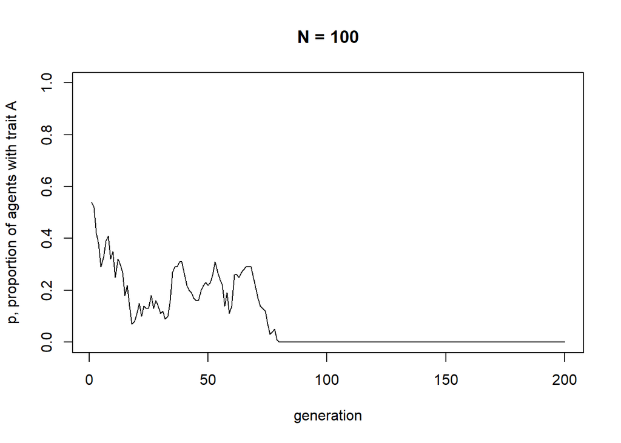

```r
plot(output$p, type = 'l', ylab = "p, proportion of agents with trait A", xlab = "generation", ylim = c(0,1), main = paste("N =", N))
```

Note the title of the graph, which gives the value of $N$ for this simulation. It’s easy to create plots and forget what the parameters were. It’s therefore a good idea to include it somewhere on the graph. There’s no need to include our other parameter, $t_{max}$, because that can be seen from the x-axis scale.

Unbiased transmission, or random copying, is by definition random, so different runs of this simulation will generate different plots. If you rerun all the code you’ll get something different again. It probably starts off hovering around 0.5 (the approximate starting value of $p$), and might go to 0 or 1 at some point. At $p = 0$ there are no $A$s and every agent possesses $B$. At $p = 1$ there are no $B$s and every agent possesses $A$. This is a typical feature of cultural drift, analogous to genetic drift: in small populations, with no selection or other directional processes operating, traits can be lost purely by chance.

Ideally we would like to repeat the simulation to explore this idea in more detail, perhaps changing some of the parameters. For example, if we increase $N$, are we more or less likely to lose one of the traits? With our code scattered about in chunks, it is hard to quickly repeat the simulation. Instead we can wrap it all up in a function, like so:

```r
UnbiasedTransmission <- function (N, t_max) {

  agent <- data.frame(trait = sample(c("A","B"), N, replace = TRUE), stringsAsFactors = FALSE)

  output <- data.frame(p = rep(NA, t_max))

  output$p[1] <- sum(agent$trait == "A") / N

  for (t in 2:t_max) {

    previous_agent <- agent  # copy agent to previous_agent dataframe

    agent <- data.frame(trait = sample(previous_agent$trait, N, replace = TRUE))  # randomly copy from previous generation

    output$p[t] <- sum(agent$trait == "A") / N  # get p and put it into output slot for this generation t

  }

  plot(output$p, type = 'l', ylab = "p, proportion of agents with trait A", xlab = "generation", ylim = c(0,1), main = paste("N =", N))

}
```

This is just all of the code snippets that we already ran above, but all within a function with parameters $N$ and $t_{max}$ as arguments to the function. Nothing will happen when you run the above code, because all you’ve done is define the function, not actually run it. The point is that we can now call the function in one go, easily changing the values of $N$ and $t_{max}$. Let’s try first with the same values of $N$ and $t_{max}$ as before, to check it works. You can re-run the code below several times, to see different dynamics. It should be different every time.

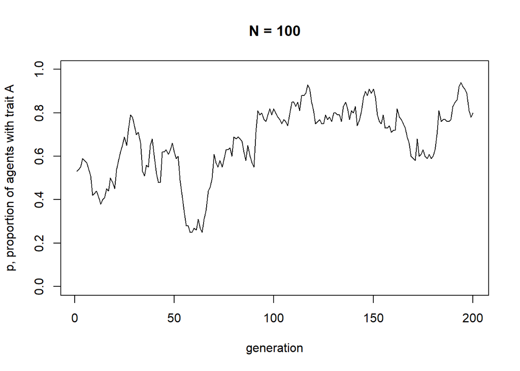

```r
UnbiasedTransmission(N = 100, t_max = 200)
```

Now let’s try changing the parameters. The following code re-runs the simulation with a much larger $N$.

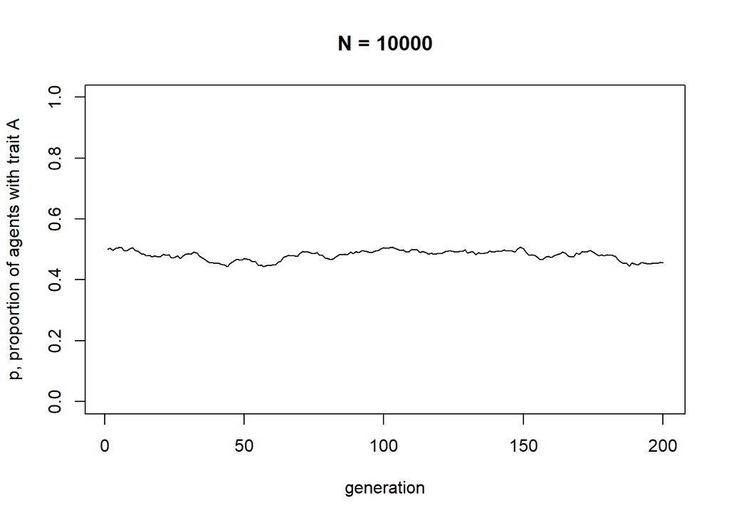

```r
UnbiasedTransmission(N = 10000, t_max = 200)
```

You should see much less fluctuation. Rarely in a population of $N = 10000$ will either trait go to fixation.

Wrapping a simulation in a function like this is good because we can easily re-run it with just a single command. However, it’s a bit laborious to manually re-run it. Say we wanted to re-run the simulation 10 times with the same parameter values to see how many times $A$ goes to fixation, and how many times $B$ goes to fixation. Currently, we’d have to manually run the **UnbiasedTransmission** function 10 times and record somewhere else what happened in each run. It would be better to automatically re-run the simulation several times and plot each run as a separate line on the same plot. We could also add a line showing the mean value of $p$ across all runs.

Let’s use a new parameter $r_{max}$ to specify the number of independent runs, and use another for-loop to cycle over the $r_{max}$ runs. We also need to expand the number of columns in the *output* dataframe, because we need one column of $p$ values for each of the runs. Let’s rewrite the **UnbiasedTransmission** function to handle multiple runs.

```r
UnbiasedTransmission <- function (N, t_max, r_max) {

  output <- as.data.frame(matrix(NA, t_max, r_max))  # create a matrix with t_max rows and r_max columns, filled with NAs, then convert to data.frame

  names(output) <- paste("run", 1:r_max, sep="")  # purely cosmetic: rename the columns with run1, run2 etc.

  for (r in 1:r_max) {

    agent <- data.frame(trait = sample(c("A","B"), N, replace = TRUE), stringsAsFactors = FALSE)  # create first generation

    output[1,r] <- sum(agent$trait == "A") / N  # add first generation's p to first row of column r

    for (t in 2:t_max) {

      previous_agent <- agent  # copy agent to previous_agent dataframe

      agent <- data.frame(trait = sample(previous_agent$trait, N, replace = TRUE))  # randomly copy from previous generation

      output[t,r] <- sum(agent$trait == "A") / N  # get p and put it into output slot for this generation t and run r

    }

  }

  # first plot a thick line for the mean p
  plot(rowMeans(output), type = 'l', ylab = "p, proportion of agents with trait A", xlab = "generation", ylim = c(0,1), lwd = 3, main = paste("N =", N))

  for (r in 1:r_max) {

    lines(output[,r], type = 'l')  # add lines for each run, up to r_max

  }

  output  # export data from function
}
```

There are a few changes here. First, we created *output* initially as a matrix, and then immediately converted it into a dataframe. This seems weird, but is just because it is easier to create a multi-row data structure using the **matrix** command than the **dataframe** command. The next command is purely cosmetic, and re-names the columns of *outcome* as run1, run2 etc.

Then we set up our $r$ loop, which executes once for each run. The code is mostly the same as before, except that we now use the “[row,column]” notation to put $p$ into the right place in *output*. The row is $t$ as before, and now the column is $r$. The **plot** command is also changed to handle multiple runs: first we plot the mean as a thick line, then we add one plotted line for each run.

Finally, the **UnbiasedTransmission** function now ends with the *output* dataframe. This means that this dataframe will be exported from the function when it is run. This can be useful for storing data from simulations wrapped in functions, otherwise that data is lost after the function is executed. In the function call below, the raw data from the simulation is put into a dataframe called *data_model1*, as a record of what happened. Run it now to display the new plot.

```r
data_model1 <- UnbiasedTransmission(N = 100, t_max = 200, r_max = 5)
```

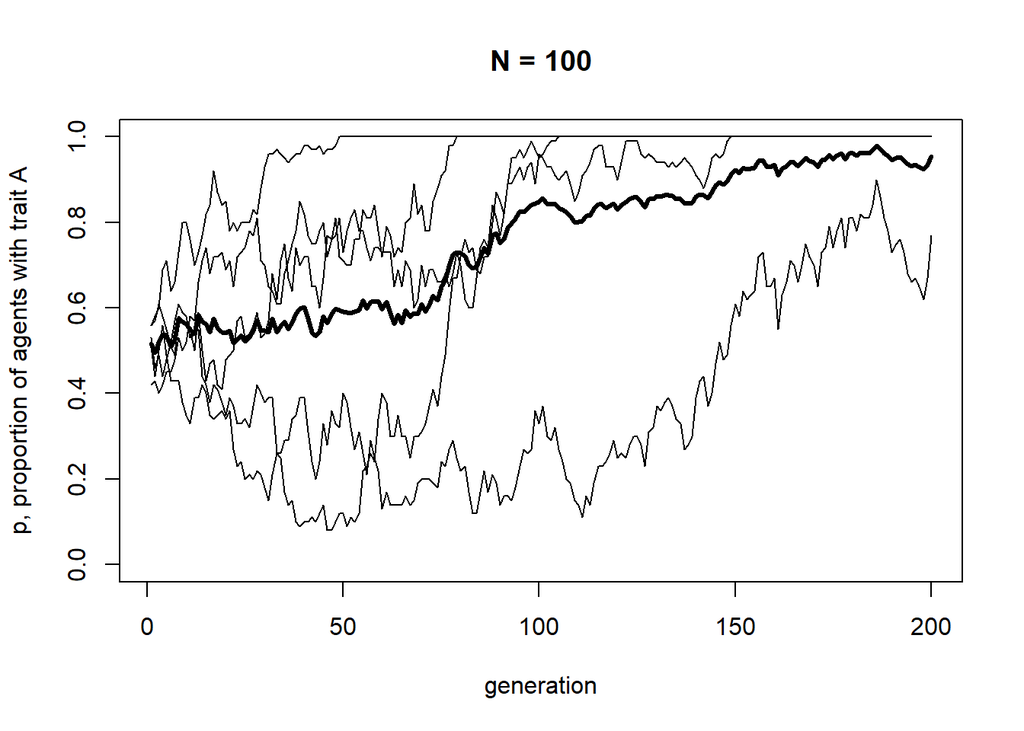

You should be able to see five independent runs of our simulation shown as regular thin lines, along with a thicker line showing the mean of these lines. Some runs have probably gone to 0 or 1, and the mean should be somewhere in between. The data is stored in *data_model1*, which we can inspect with **head**:

```r
head(data_model1)
```

```
##   run1 run2 run3 run4 run5
## 1 0.56 0.42 0.56 0.51 0.53
## 2 0.58 0.43 0.57 0.44 0.46
## 3 0.60 0.40 0.61 0.50 0.49
## 4 0.69 0.42 0.58 0.56 0.44
## 5 0.71 0.45 0.55 0.49 0.48
## 6 0.64 0.45 0.51 0.43 0.52
```

Now let’s run the updated **UnbiasedTransmission** model with $N = 10000$, to compare with $N = 100$.

```r
data_model1 <- UnbiasedTransmission(N = 10000, t_max = 200, r_max = 5)
```

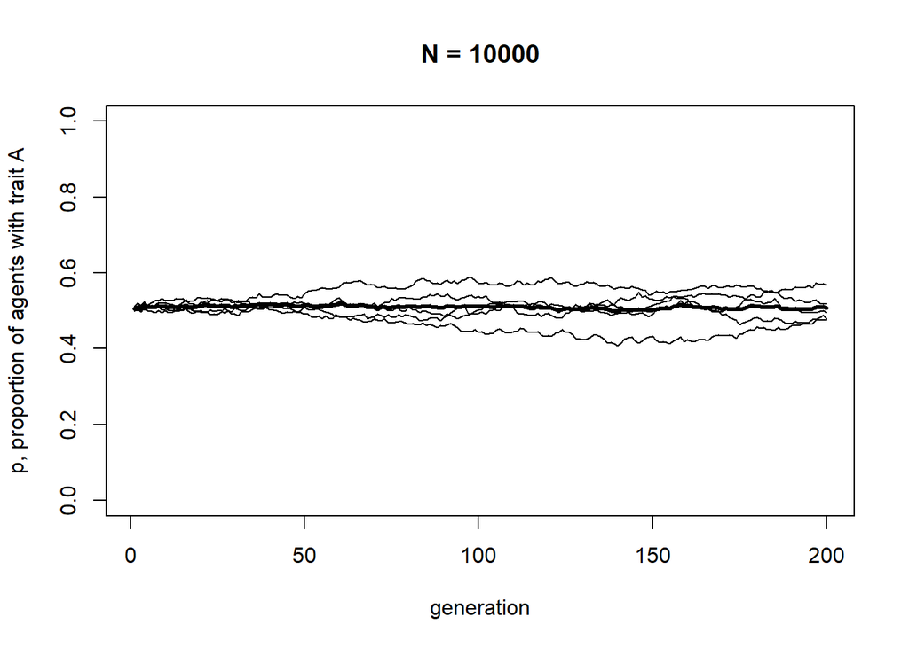

The mean line should be almost exactly at $p = 0.5$ now, with the five independent runs fairly close to it.

Let’s add one final modification. So far the starting frequencies of $A$ and $B$ have been the same, roughly 0.5 each. But what if we were to start at different initial frequencies of $A$ and $B$? Say, $p = 0.2$ or $p = 0.9$? Would unbiased transmission keep $p$ at these initial values, or would it go to $p = 0.5$ as we have found so far?

To find out, we can add another parameter, $p_0$, which specifies the initial probability of drawing an $A$ rather than a $B$ in the first generation. Previously this was always $p_0 = 0.5$, but in the new function below we add it to the **sample** function to weight the initial allocation of traits in $t = 1$.

```r
UnbiasedTransmission <- function (N, p_0, t_max, r_max) {

  output <- as.data.frame(matrix(NA,t_max,r_max))  # create a matrix with t_max rows and r_max columns, filled with NAs, then convert to data.frame

  names(output) <- paste("run", 1:r_max, sep="")  # purely cosmetic: rename the columns with run1, run2 etc.

  for (r in 1:r_max) {

    agent <- data.frame(trait = sample(c("A","B"), N, replace = TRUE, prob = c(p_0,1-p_0)), stringsAsFactors = FALSE)  # create first generation

    output[1,r] <- sum(agent$trait == "A") / N  # add first generation's p to first row of column r

    for (t in 2:t_max) {

      previous_agent <- agent  # copy agent to previous_agent dataframe

      agent <- data.frame(trait = sample(previous_agent$trait, N, replace = TRUE))  # randomly copy from previous generation

      output[t,r] <- sum(agent$trait == "A") / N  # get p and put it into output slot for this generation t and run r

    }

  }

  # first plot a thick line for the mean p
  plot(rowMeans(output), type = 'l', ylab = "p, proportion of agents with trait A", xlab = "generation", ylim = c(0,1), lwd = 3, main = paste("N =", N))

  for (r in 1:r_max) {

    lines(output[,r], type = 'l')  # add lines for each run, up to r_max

  }

  output  # export data from function
}
```

The only change here is the addition of $p_0$ as a definable parameter for the function, and the prob argument in the **sample** command. The prob argument gives the probability of picking each option, in our case $A$ and $B$, in the first generation. The probability of $A$ is now $p_0$, and the probability of $B$ is now $1 - p_0$. Let’s see what happens with a different value of $p_0$.

```r
data_model1 <- UnbiasedTransmission(N = 10000, p_0 = 0.2, t_max = 200, r_max = 5)
```

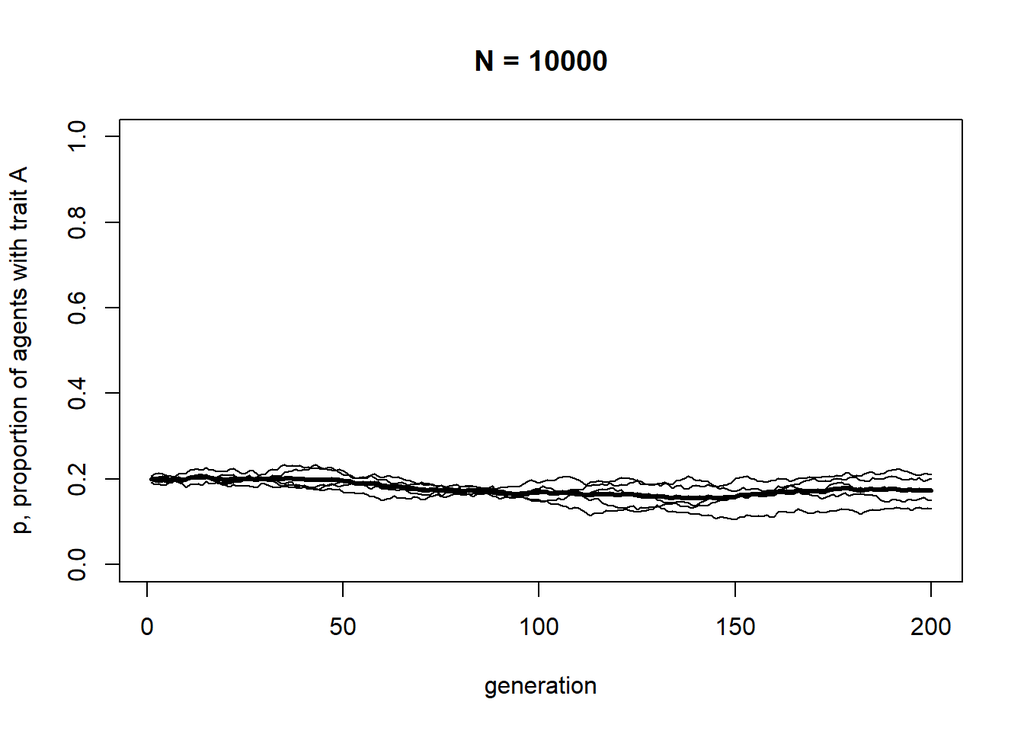

With $p_0 = 0.2$, trait frequencies stay at $p = 0.2$. Unbiased transmission is truly non-directional: it maintains trait frequencies at whatever they were in the previous generation, barring random fluctuations caused by small population sizes.

### Summary of Model 1

Even this extremely simple model provides some valuable insights. First, unbiased transmission does not in itself change trait frequencies. As long as populations are large, trait frequencies remain the same.

Second, the smaller the population size, the more likely traits are to be lost by chance. This is a basic insight from population genetics, known there as genetic drift, but it can also be applied to cultural evolution. Many studies have tested (and some supported) the idea that population size and other demographic factors can shape cultural diversity.

Furthermore, generating expectations about cultural change under simple assumptions like random cultural drift can be useful for detecting non-random patterns like selection: if we don’t have a baseline, we won’t know selection or other directional processes when we see them.

In Model 1 we have introduced several programming techniques that will be useful in later models. We’ve seen how to use dataframes to hold characteristics of agents, how to use loops to cycle through generations and simulation runs, how to use **sample** to pick randomly from sets of elements, how to wrap simulations in functions to easily re-run them with different parameter values, how to plot the results of simulations, and how to store the output of the simulation in a dataframe that persists after the simulation function is run.

## Analytical Appendix

If $p$ is the frequency of $A$ in one generation, we are interested in calculating $p'$, the frequency of $A$ in the next generation under the assumption of unbiased transmission. Each new individual in the next generation picks a demonstrator at random from amongst the previous generation. The demonstrator will have $A$ with probability $p$. The frequency of $A$ in the next generation, then, is simply the frequency of $A$ in the previous generation:

$$p' = p \hspace{30 mm}(1.1)$$

Equation 1.1 simply says that under unbiased transmission there is no change in $p$ over time. If, as we assumed above, the initial value of $p$ in a particular population is $p_0$, then the equilibrium value of $p$, $p^*$, at which there is no change in $p$ over time, is just $p_0$. We can plot this recursion, to recreate the final simulation plot above:

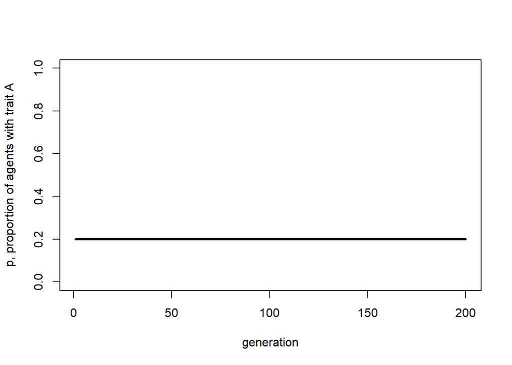

```r
p_0 <- 0.2
t_max <- 200
p <- rep(NA, t_max)
p[1] <- p_0
for (i in 2:t_max) {
  p[i] <- p[i-1]
}
plot(p, type = 'l', ylab = "p, proportion of agents with trait A", xlab = "generation", ylim = c(0,1), lwd = 3)
```

Don’t worry, it gets more complicated than this in later chapters. The key point here is that analytical (or deterministic) models assume infinite populations (note there is no $N$ in the above recursion) and no stochasticity. Simulations with very large populations should give the same results as analytical models. Basically, the closer we can get in stochastic models to the assumption of infinite populations, the closer the match to infinite-population deterministic models. Deterministic models give the ideal case; stochastic models permit more realistic dynamics based on finite populations. More generally, creating deterministic recursion-based models can be a good way of verifying simulation models, and vice versa: if the same dynamics occur in both agent-based and recursion-based models, then we can be more confident that those dynamics are genuine and not the result of a programming error or mathematical mistake. ***